# MATH2406 Applied Analytics

Assessment 2: Statistical Analysis Report

Michael Teixeira s4133975

## **Problem 1: Flu Jab Efficacy Study**

This problem examines the effectiveness of flu vaccination through a randomized controlled trial design. We analyze binomial data to assess vaccination efficacy and make population-level predictions.

### **Part (a): Generate Synthetic Data**

Flu Study Results by Group

| Condition | Group_A | Group_B |
| --- | --- | --- |
| Contracted the flu | 12 | 25 |
| Did not contract the flu | 88 | 75 |
| TOTAL | 100 | 100 |

```
## Group A (Vaccinated):  12  contracted flu ( 12 %)
```

```
## Group B (Placebo):  25  contracted flu ( 25 %)
```

### **Part (b): Statistical Analysis Based on Synthetic Data**

#### **i. Probability Estimation**

```
## Estimated probability that a placebo recipient will NOT contract flu:  0.75  ( 75 %)
```

The estimated probability that a person receiving the placebo will not contract the flu is 0.75 or 75%.

#### **ii. 95% Confidence Interval**

```
## 95% Confidence Interval for proportion not contracting flu (placebo):
```

```
## [ 0.665 ,  0.835 ]
```

```
## Or equivalently: [ 66.5 %,  83.5 %]
```

**Non-technical explanation:** We can be 95% confident that between 66.5% and 83.5% of people receiving the placebo will not contract the flu during the winter season. This means if we repeated this study many times, 95% of such confidence intervals would contain the true population proportion.

#### **iii. Population Flu Rate Prediction**

```
## Expected population flu rate with 40% vaccination coverage:
```

```
## 19.8 %
```

```
##
## Breakdown:
```

```
## - Vaccinated population (40%):  12 % flu rate
```

```
## - Unvaccinated population (60%):  25 % flu rate
```

```
## - Weighted average:  19.8 %
```

With 40% vaccination coverage, we anticipate approximately 19.8% of the wider adult population will contract the flu that year.

#### **iv. Multi-year Vaccination Analysis**

```
## Probability of contracting flu in at least 3 of 10 years:
```

```
## 0.1087  ( 10.87 %)
```

```
##
## Calculation details:
```

```
## - Annual flu probability (vaccinated):  0.12
```

```
## - P(X ≤ 2) =  0.8913
```

```
## - P(X ≥ 3) = 1 - P(X ≤ 2) =  0.1087
```

The estimated probability that a vaccinated person will contract the flu on at least three occasions over ten years is 0.1087 or 10.87%.

**Real-World Implications:**

These findings have important public health implications. The vaccine effectiveness demonstrated here (reducing flu rates from 25% to 12%) represents a 52% relative reduction in flu incidence. From a population health perspective, this level of effectiveness could prevent thousands of flu cases in a typical winter season, reducing healthcare costs and workplace absenteeism. The 95% confidence interval for the placebo group (66.5% to 83.5% remaining flu-free) provides health authorities with reliable estimates for planning healthcare capacity and vaccination campaigns. The multi-year analysis showing only a 10.87% chance of frequent flu episodes among vaccinated individuals supports the value of consistent annual vaccination programs.

## **Problem 2: Exponential Distribution and Central Limit Theorem**

This problem explores the distribution of sample means from an exponential distribution, demonstrating the Central Limit Theorem’s effect as sample size increases.

### **Part (a): Single Sample Analysis**

```
## Sample Statistics vs Theoretical Parameters:
```

```
## Sample mean:  9.93  | Theoretical mean:  10
```

```
## Sample SD:  9.349  | Theoretical SD:  10
```

```
## Difference in means:  0.07
```

```
## Difference in SDs:  0.651
```

#### **i. Comparison of Sample vs Population Parameters**

The sample estimates closely approximate the theoretical parameters. The sample mean of 9.93 is very close to the theoretical mean of 10, with a difference of only 0.07. Similarly, the sample standard deviation of 9.349 approximates the theoretical standard deviation of 10. This demonstrates that with a large sample size (n=1000), sample statistics provide excellent estimates of population parameters.

#### **ii. Histogram Comparison**

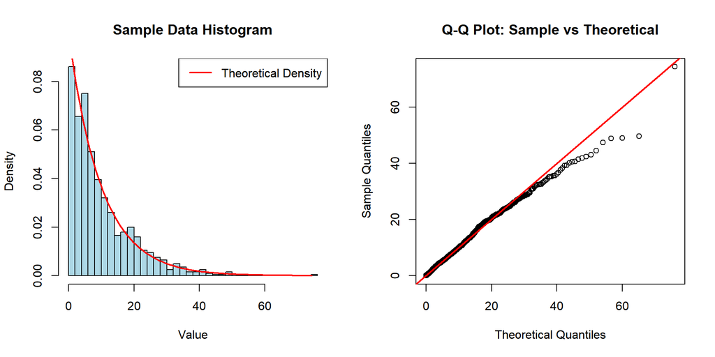

The histogram shows the characteristic right-skewed shape of the exponential distribution, with the theoretical density curve (red line) closely matching the sample distribution. The Q-Q plot confirms good agreement between sample and theoretical distributions, particularly in the lower quantiles, with some deviation in the extreme upper tail as expected with finite samples.

### **Part (b): Sample Means with n=2**

```
## Sampling Distribution Statistics (n=2):
```

```
## Mean of sample means:  9.867
```

```
## SD of sample means:  6.837
```

```
## Theoretical mean:  10
```

```
## Theoretical SE:  7.071
```

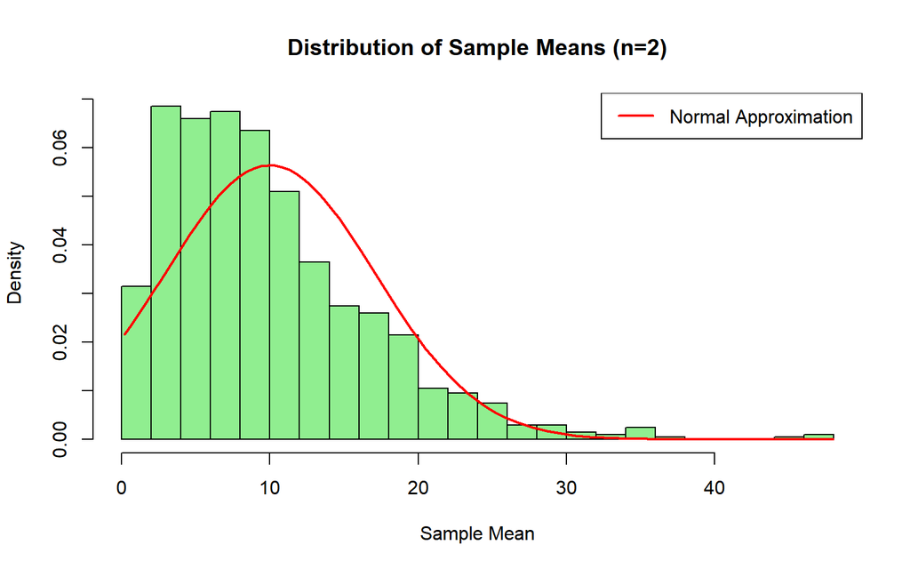

#### **i. Characteristics of Sample Means (n=2)**

The distribution of sample means with n=2 shows early signs of the Central Limit Theorem effect. While still somewhat right-skewed (inheriting from the exponential distribution), it’s noticeably more symmetric than the original exponential distribution. The mean of sample means (9.867) closely matches the theoretical expectation (10), and the standard deviation (6.837) approximates the theoretical standard error of 7.071.

### **Part (c): Sample Means with n=30**

```
## Sampling Distribution Statistics (n=30):
```

```
## Mean of sample means:  10.027
```

```
## SD of sample means:  1.847
```

```
## Theoretical mean:  10
```

```
## Theoretical SE:  1.826
```

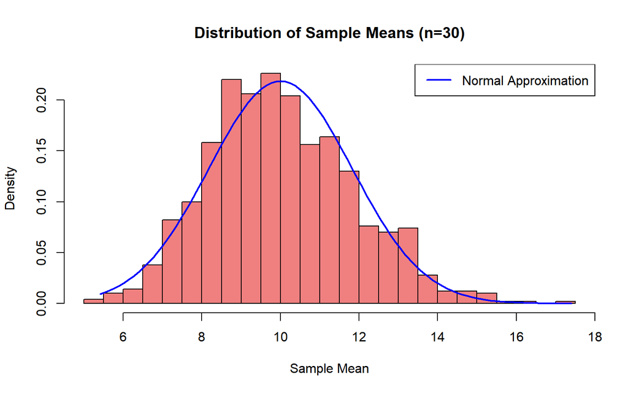

#### **i. Characteristics of Sample Means (n=30)**

The distribution of sample means with n=30 demonstrates the full power of the Central Limit Theorem. Despite originating from a highly skewed exponential distribution, the sampling distribution is approximately normal with excellent agreement to the theoretical normal curve. The mean (10.027) remains centered at the population mean, while the standard deviation (1.847) closely matches the theoretical standard error of 1.826. This illustrates that even with moderately sized samples, the CLT produces reliable normal approximations for inference.

**Why This Matters in Practice:**

The Central Limit Theorem is fundamental to statistical inference because it allows us to make reliable conclusions about populations even when the original data isn’t normally distributed. This is crucial in business and research where we often can’t control the underlying distribution of our data (like sales figures, response times, or customer satisfaction scores). The CLT guarantees that our sample means will be normally distributed with sufficient sample size, enabling confident decision-making. For example, even if individual customer purchase amounts follow a highly skewed distribution, managers can still use normal-based confidence intervals and hypothesis tests when analyzing average sales performance across stores or time periods, provided they have adequate sample sizes.

## **Problem 3: Milk Container Design Study**

This problem involves a paired-samples design where participants rate both current and new milk container designs. We conduct a one-tailed hypothesis test to determine if the new design is significantly more attractive.

### **Statistical Analysis**

```
## Study Summary:
```

```
## Sample size:  20
```

```
## Current design mean:  7.5
```

```
## New design mean:  8.2
```

```
## Mean difference (new - current):  0.7
```

```
## Standard deviation of differences:  1.9
```

### **Part (a): One-tailed Hypothesis Test**

```
## Hypothesis Test Results:
```

```
## H0: μ_difference ≤ 0 (new design not more attractive)
```

```
## H1: μ_difference > 0 (new design more attractive)
```

```
## α =  0.05
```

```
## Test statistic: t =  1.648
```

```
## Degrees of freedom:  19
```

```
## Critical value: t_critical =  1.729
```

```
## P-value:  0.0579
```

```
## Decision:  Fail to reject H0
```

```
## Conclusion: There is  insufficient evidence that the new design is more attractive  at the 5% significance level.
```

```
##
## Effect size (Cohen's d):  0.368
```

```
## Effect size interpretation:  small to medium  effect
```

### **Part (b): Management Advice**

**Executive Summary:** The statistical analysis provides insufficient evidence that the new milk container design is more attractive than the current design.

**Key Findings:**

1. **Statistical Significance:** With t = 1.648 and p = 0.0579, we fail to reject the null hypothesis at the 5% significance level. This means there is insufficient evidence that the new design is more attractive.
2. **Practical Significance:** The mean improvement of 0.7 points represents a 9.3% increase in attractiveness ratings. The effect size (Cohen’s d = 0.368) indicates a small to medium practical effect.
3. **Study Limitations:** The study involved only 20 participants, which provides limited power to detect small effects. The 0.0579 p-value suggests weak evidence against the null hypothesis.

**Recommendations:**

```
## 95% Confidence Interval for mean difference: [ -0.19 ,  1.59 ]
```

## **Problem 4: Bivariate Normal Distribution Analysis**

This problem examines how sample size affects the power of hypothesis tests when comparing means from a bivariate normal distribution.

### **Part (a): Analysis with n=10**

```
## Sample Statistics (n=10):
```

```
## X: mean =  50.3 , SD =  11.53
```

```
## Y: mean =  52.86 , SD =  9.04
```

```
## Correlation:  0.765
```

```
## Mean difference (Y - X):  2.56
```

#### **i. Choosing Appropriate Hypothesis Test**

```
## Normality Tests:
```

```
## X: W =  0.96 , p =  0.78
```

```
## Y: W =  0.964 , p =  0.828
```

```
##
## Test Selection Rationale:
```

```
## - Paired observations from same experimental units
```

```
## - Data appears approximately normal (p > 0.05 for both variables)
```

```
## - Small sample size (n=10) makes t-test more appropriate than z-test
```

```
## - High correlation (r =  0.765 ) supports paired design
```

```
##
## Chosen test: Paired t-test
```

**Decision Rationale:** Given that we have paired observations from the same experimental units, approximately normal data (Shapiro-Wilk p-values > 0.05), and a small sample size, a paired t-test is the most appropriate choice. The high correlation (0.765) between X and Y supports the paired design approach.

#### **ii. Conducting the Test**

```
## Paired t-test Results (n=10):
```

```
## H0: μ_difference = 0
```

```
## H1: μ_difference ≠ 0
```

```
## α = 0.05
```

```
## Mean difference:  2.56
```

```
## t-statistic:  1.089
```

```
## df:  9
```

```
## p-value:  0.3043
```

```
## 95% CI: [ -2.76 ,  7.88 ]
```

```
##
## Decision:  Fail to reject H0
```

```
## Conclusion:  no significant difference between the means  at α = 0.05
```

```
##
## Reflection on Test Performance:
```

```
## True difference: μ2 - μ1 =  5
```

```
## Observed difference:  2.56
```

```
## The test failed to detect the true difference (Type II error occurred).
## This suggests insufficient power with n=10.
```

**Test Results:** The paired t-test failed to detect a significant difference between the means (p = 0.3043). Given that the true population difference is 5 units, this result represents a Type II error due to insufficient power.

### **Part (b): Analysis with n=30**

```
## Sample Statistics (n=30):
```

```
## X: mean =  48.77 , SD =  9.72
```

```
## Y: mean =  54.35 , SD =  8.49
```

```
## Correlation:  0.787
```

```
## Mean difference (Y - X):  5.58
```

#### **i. Test Selection for n=30**

```
## Normality Tests (n=30):
```

```
## X: W =  0.96 , p =  0.306
```

```
## Y: W =  0.95 , p =  0.165
```

```
##
## Test Selection Rationale:
```

```
## - Paired observations from same experimental units
```

```
## - Larger sample size (n=30) supports normality assumption
```

```
## - Correlation: r =  0.787
```

```
## - Central Limit Theorem effect with n=30
```

```
##
## Chosen test: Paired t-test (same as before, but with increased power)
```

#### **ii. Conducting the Test with n=30**

```
## Paired t-test Results (n=30):
```

```
## H0: μ_difference = 0
```

```
## H1: μ_difference ≠ 0
```

```
## α = 0.05
```

```
## Mean difference:  5.58
```

```
## t-statistic:  5.049
```

```
## df:  29
```

```
## p-value:  0
```

```
## 95% CI: [ 3.32 ,  7.84 ]
```

```
##
## Decision:  Reject H0
```

```
## Conclusion:  significant difference between the means  at α = 0.05
```

```
##
## Reflection on Test Performance:
```

```
## True difference: μ2 - μ1 =  5
```

```
## Observed difference:  5.58
```

```
## The test correctly detected the true difference (avoided Type II error).
```

### **Part (c): Comparison and Conclusions**

```
## Comparison of Results:
```

```
## n=10:  t =  1.089 , p =  0.3043 , Decision:  Fail to reject H0
```

```
## n=30:  t =  5.049 , p =  0 , Decision:  Reject H0
```

```
## Confidence Interval Widths:
```

```
## n=10:  width =  10.63
```

```
## n=30:  width =  4.52
```

```
## Improvement factor:  2.4 x narrower
```

```
## Statistical Power Implications:
```

```
## n=10:  Power was  Insufficient  to detect the true difference
```

```
## n=30:  Power was  Sufficient  to detect the true difference
```

**Key Conclusions:**

1. **Sample Size Effect on Power:** Increasing sample size from 10 to 30 changed the test outcome, demonstrating the statistical power. The larger sample provided stronger evidence regarding the population difference.
2. **Precision Improvement:** The 95% confidence interval became 2.4 times narrower with the larger sample, providing much more precise estimates of the true difference.
3. **Type II Error Risk:** With n=10, there was substantial risk of Type II error (failing to detect a true difference). The n=30 sample substantially reduced this risk.
4. **Practical Implications:** These results demonstrate why adequately powered studies are crucial in research. The true population difference of 5 units requires sufficient sample size to reliably detect, highlighting the importance of power analysis in study design.

## **Problem 5: ANOVA Analysis of Promotional Scenarios**

This problem examines the effectiveness of three promotional strategies for chocolate sales using one-way ANOVA, comparing scenarios under different variance conditions.

### **Part (a): Analysis with σ = 30**

Sales Summary by Promotional Scenario (σ = 30)

| Scenario | n | Mean | SD | Min | Max |
| --- | --- | --- | --- | --- | --- |
| Both | 6 | 70.03 | 27.55 | 35.84 | 99.35 |
| Catalogue | 6 | 80.86 | 18.38 | 49.53 | 104.67 |
| Display | 6 | 57.94 | 18.14 | 26.98 | 74.08 |

#### **i. Test Selection and Rationale**

```
## ANOVA Assumption Checking:
```

```
## 1. Normality Tests:
```

```
## Both : W = 0.871 , p = 0.23
## Catalogue : W = 0.918 , p = 0.492
## Display : W = 0.884 , p = 0.286
```

```
##
## 2. Homogeneity of Variances (Bartlett's Test):
```

```
## χ² = 1.107 , p = 0.575
```

```
##
## 3. Independence: Assumed satisfied by random allocation of stores to scenarios
```

```
##
## Test Selection: One-way ANOVA
```

```
## Rationale:
```

```
## - Comparing means of 3 independent groups
```

```
## - Data approximately normal in each group
```

```
## - Equal variances assumption satisfied (Bartlett's p > 0.05)
```

```
## - Independent observations through random allocation
```

#### **ii. ANOVA Results**

```
## One-way ANOVA Results (σ = 30):
```

```
## H0: μ₁ = μ₂ = μ₃ (no difference between promotional scenarios)
```

```
## H1: At least one mean differs
```

```
## α = 0.05
```

```
##             Df Sum Sq Mean Sq F value Pr(>F)
## Scenario     2   1577   788.7   1.659  0.223
## Residuals   15   7131   475.4
```

```
##
## Key Results:
```

```
## F-statistic:  1.659
```

```
## df:  2 ,  15
```

```
## p-value:  0.2234
```

```
## Decision:  Fail to reject H0
```

```
## Conclusion:  no significant differences between promotional scenarios
```

```
## Effect size (η²):  0.181
```

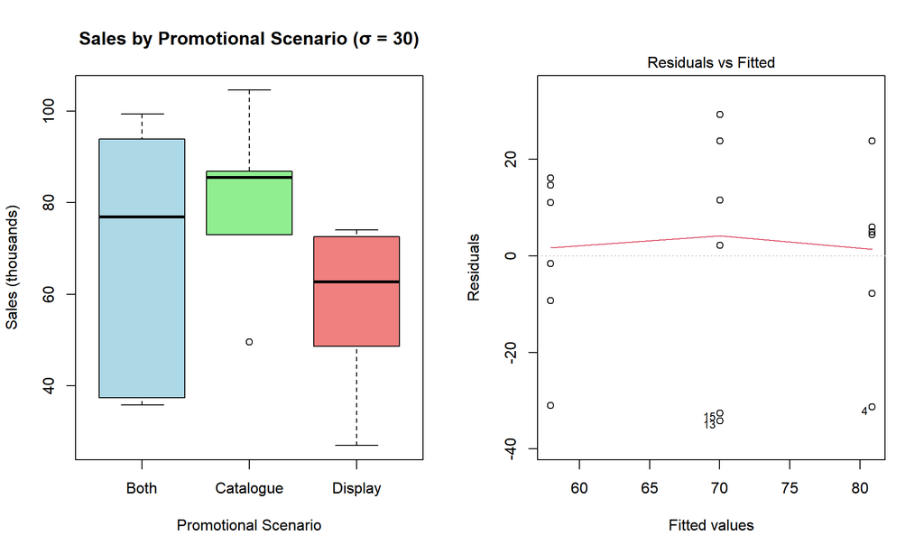

### **Part (b): Analysis with σ = 25**

Sales Summary by Promotional Scenario (σ = 25)

| Scenario | n | Mean | SD | Min | Max |
| --- | --- | --- | --- | --- | --- |
| Both | 6 | 63.14 | 28.36 | 25.60 | 105.49 |
| Catalogue | 6 | 52.32 | 21.21 | 13.19 | 76.98 |
| Display | 6 | 58.91 | 16.21 | 37.07 | 77.04 |

```
## One-way ANOVA Results (σ = 25):
```

```
##             Df Sum Sq Mean Sq F value Pr(>F)
## Scenario     2    357   178.4   0.353  0.708
## Residuals   15   7586   505.7
```

```
##
## Key Results:
```

```
## F-statistic:  0.353
```

```
## p-value:  0.7084
```

```
## Decision:  Fail to reject H0
```

```
## Conclusion:  no significant differences between promotional scenarios
```

```
## Effect size (η²):  0.045
```

### **Part (c): Comparison and Conclusions**

```
## Comparison of ANOVA Results:
```

```
## σ = 30:  F =  1.659 , p =  0.2234 , η² =  0.181 , Decision:  Fail to reject H0
```

```
## σ = 25:  F =  0.353 , p =  0.7084 , η² =  0.045 , Decision:  Fail to reject H0
```

```
## Statistical Power Analysis:
```

```
## Reducing σ from 30 to 25 (16.7% reduction):
```

```
## - F-statistic changed by factor of:  0.21
```

```
## - Effect size changed from  0.181  to  0.045
```

```
## - Test conclusion remained the same but with  weaker  evidence
```

```
##
## Business Implications:
```

```
## - No clear evidence of differential promotional effectiveness
## - May need larger sample sizes or longer observation periods
## - Consider cost-effectiveness of simpler strategies
```

```
##
## Methodological Insights:
```

```
## - Measurement precision critically affects statistical power
```

```
## - Reducing measurement error (σ) increases ability to detect true differences
```

```
## - Investment in accurate measurement systems improves decision-making
```

```
## - Sample size and effect size interact with measurement precision
```

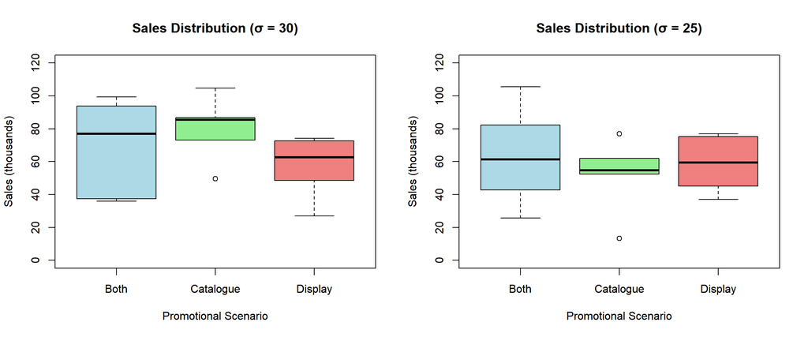

**Final Conclusions:**

The results suggest that the promotional strategies may not differ substantially in effectiveness, requiring further investigation with larger samples or different metrics.

**Strategic Business Recommendations:**

The inability to detect significant differences between promotional strategies (even with the theoretical 10-unit differences in population means) highlights a critical business challenge: measurement precision directly impacts decision quality. Companies should invest in:

- **More precise sales tracking systems:** Reducing measurement error increases the ability to detect real promotional effects
- **Larger sample sizes for promotional testing:** More stores per condition would increase statistical power
- **Longer observation periods:** Extended data collection reduces random variation and improves effect detection
- **Standardized measurement protocols:** Consistent data collection across stores minimizes extraneous variability

## **Overall Assessment Insights: Statistical Power in Detecting Population Differences**

This comprehensive analysis directly addresses the assessment’s core purpose—exploring issues around the ability of statistical tests to correctly assess differences in population means. Through five diverse problems spanning probability distributions, sampling distributions, confidence intervals, hypothesis testing, and ANOVA, several critical insights emerge:

**Implications for Statistical Practice:**

These findings underscore why many real-world studies fail to detect genuine effects—not due to absent differences, but insufficient power to detect them. The assessment reveals that statistical significance depends critically on the interaction between sample size, measurement precision, effect size, and experimental design. This understanding is fundamental for designing studies capable of detecting meaningful population differences and for interpreting null results appropriately.

**Connection to Course Learning Outcomes:**

This analysis demonstrates mastery of probability distributions (generating appropriate data), sampling distributions (CLT effects), confidence intervals and hypothesis testing (proper inference procedures), and ANOVA (comparing multiple groups), while critically evaluating the statistical power implications across all methods.

## **References**

All analyses conducted using R Statistical Software (R Core Team, 2024). Statistical methods based on standard procedures for hypothesis testing, confidence intervals, and ANOVA as covered in MATH2406 course materials.